# Untitled

2025-04-09

Install any packages that will be used for this project

```r
if(!require(readxl)){install.packages("readxl")}
library(readxl)
if(!require(dplyr)){install.packages("dplyr")}
library(dplyr)
if(!require(lubridate)){install.packages("lubridate")}
library(lubridate)
if(!require(tidyverse)){install.packages("tidyverse")}
library(tidyverse)
if (!require(glmnet)) install.packages("glmnet")
library(glmnet)
if (!require(keras)) install.packages("keras")
library(keras)
if (!require(elasticnet)) install.packages("elasticnet")
library(elasticnet)
if (!require(tidyr)) install.packages("tidyr")
library(tidyr)
```

Data Wrangling  
Read the data in to the environment

```r
# Use local drive address to load the data
load("F:/Waterloo/AFM/AFM 423/data_ml.RData")
# preview first few rows of the dataset
head(data_ml, 6)
```

```
## # A tibble: 6 × 99
##   stock_id date       Advt_12M_Usd Advt_3M_Usd Advt_6M_Usd Asset_Turnover Bb_Yld
##      <int> <date>            <dbl>       <dbl>       <dbl>          <dbl>  <dbl>
## 1       13 2006-12-31         0.25        0.33        0.27           0.22   0.33
## 2       13 2007-01-31         0.25        0.32        0.28           0.22   0.4
## 3       13 2007-02-28         0.26        0.3         0.3            0.22   0.15
## 4       17 2015-03-31         0.73        0.64        0.7            0.4    0.47
## 5       17 2015-04-30         0.72        0.62        0.66           0.4    0.46
## 6       17 2015-05-31         0.71        0.63        0.64           0.4    0.47
## # ℹ 92 more variables: Bv <dbl>, Capex_Ps_Cf <dbl>, Capex_Sales <dbl>,
## #   Cash_Div_Cf <dbl>, Cash_Per_Share <dbl>, Cf_Sales <dbl>, Debtequity <dbl>,
## #   Div_Yld <dbl>, Dps <dbl>, Ebit_Bv <dbl>, Ebit_Noa <dbl>, Ebit_Oa <dbl>,
## #   Ebit_Ta <dbl>, Ebitda_Margin <dbl>, Eps <dbl>, Eps_Basic <dbl>,
## #   Eps_Basic_Gr <dbl>, Eps_Contin_Oper <dbl>, Eps_Dil <dbl>, Ev <dbl>,
## #   Ev_Ebitda <dbl>, Fa_Ci <dbl>, Fcf <dbl>, Fcf_Bv <dbl>, Fcf_Ce <dbl>,
## #   Fcf_Margin <dbl>, Fcf_Noa <dbl>, Fcf_Oa <dbl>, Fcf_Ta <dbl>, …
```

The first column is a unique identifier for each stock and the second column is the observation date. The other columns are financial or fundamental features for example, Advt_12M_Usd would represents average trading volume over the past 12 months (in USD).

Cleanning the data

```r
# Clean and sort the dataset
data_ml <- data_ml %>%
  distinct() %>% #remove duplicates
  filter(date > "1999-12-31",         # Keep the date with sufficient data points
         date < "2019-01-01") %>%
    arrange(stock_id, date)             # Order the data
```

Now we are going to create a new column “target_return” to store our predicted future stock returns

```r
data_ml <- data_ml %>%
  mutate(target_return = R1M_Usd) %>%
  filter(!is.na(target_return))  # Remove rows without a future return
```

Then We define our train samples as the following:  
Training set: from 2000-01-01 to 2013-12-31  
Validation set: from 2014-01-01 to 2016-12-31  
Testing Set: from 2017-01-01 to 2018-12-31

```r
# Split into training, validation, and test sets
training_set <- filter(data_ml, date < as.Date("2014-01-15"))
validation_set <- filter(data_ml, (date >= as.Date("2014-01-15")
                                   & date < as.Date("2017-01-15")))
testing_set <- filter(data_ml, date >= as.Date("2017-01-15"))
```

Prepare data matrices

```r
# Define features to be used for LASSO and NN
features <- training_set %>%
  select(-stock_id, -date, -R1M_Usd, -R3M_Usd, -R6M_Usd, -R12M_Usd, -target_return) %>%
  colnames()

# Create matrix inputs for glmnet
X_train <- as.matrix(training_set[, features])
y_train <- training_set$target_return

X_val <- as.matrix(validation_set[, features])
y_val <- validation_set$target_return

X_test <- as.matrix(testing_set[, features])
y_test <- testing_set$target_return
```

Train Lasso with cross-validation

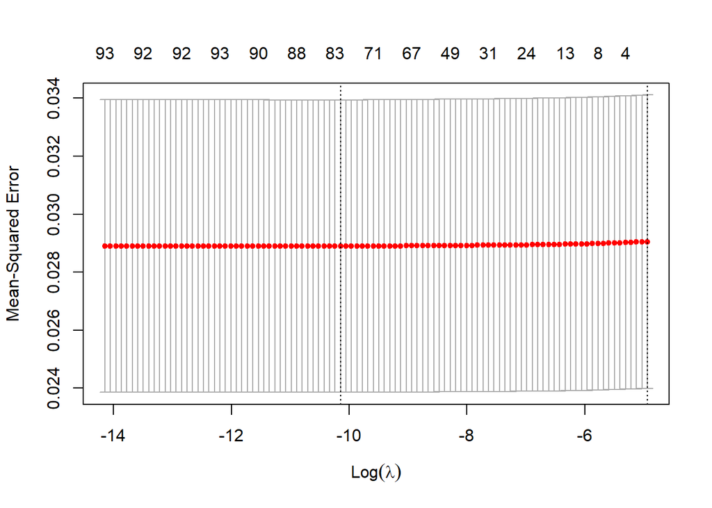

```r
# Train LASSO model with cross-validation
cv_lasso <- cv.glmnet(X_train, y_train, alpha = 1, nfolds = 10)

# plot CV error vs. lambda
plot(cv_lasso)
```

```r
# Choose lambda with lowest CV error
best_lambda <- cv_lasso$lambda.min
cat("Best lambda:", best_lambda, "\n")
```

```
## Best lambda: 3.919066e-05
```

Evaluate model on validation

```r
# Predict and evaluate
pred_val <- predict(cv_lasso, s = best_lambda, newx = X_val)
pred_test <- predict(cv_lasso, s = best_lambda, newx = X_test)

# Compute RMSE
rmse <- function(actual, predicted) {
  sqrt(mean((actual - predicted)^2))
}

cat("Validation RMSE:", rmse(y_val, pred_val), "\n")
```

```
## Validation RMSE: 0.1032521
```

```r
cat("Test RMSE:", rmse(y_test, pred_test), "\n")
```

```
## Test RMSE: 0.2802891
```

Extract Lasso Features (non-zero coefficients)

```r
# Extract coefficients at best lambda
lasso_coef <- coef(cv_lasso, s = best_lambda)
selected_features <- rownames(lasso_coef)[which(lasso_coef[, 1] != 0)]
selected_features <- setdiff(selected_features, "(Intercept)")  # remove intercept
print(selected_features)
```

```
##  [1] "Advt_12M_Usd"                   "Advt_3M_Usd"
##  [3] "Asset_Turnover"                 "Bb_Yld"
##  [5] "Bv"                             "Capex_Ps_Cf"
##  [7] "Capex_Sales"                    "Cash_Div_Cf"
##  [9] "Cash_Per_Share"                 "Cf_Sales"
## [11] "Debtequity"                     "Div_Yld"
## [13] "Dps"                            "Ebit_Bv"
## [15] "Ebit_Noa"                       "Ebit_Oa"
## [17] "Ebit_Ta"                        "Ebitda_Margin"
## [19] "Eps"                            "Eps_Basic"
## [21] "Eps_Basic_Gr"                   "Eps_Contin_Oper"
## [23] "Eps_Dil"                        "Ev_Ebitda"
## [25] "Fa_Ci"                          "Fcf"
## [27] "Fcf_Bv"                         "Fcf_Ce"
## [29] "Fcf_Margin"                     "Fcf_Noa"
```

[output cut: 25 more lines]

These are the features that out Lasso model thinks matter for predicting the future return.

Prepare the data needed for NN

```r
# Prepare training, validation, and test sets using only selected LASSO features
X_train_nn <- as.matrix(training_set[, selected_features])
X_val_nn   <- as.matrix(validation_set[, selected_features])
X_test_nn  <- as.matrix(testing_set[, selected_features])

y_train_nn <- training_set$target_return
y_val_nn   <- validation_set$target_return
y_test_nn  <- testing_set$target_return
```

Build & Train Neural Network

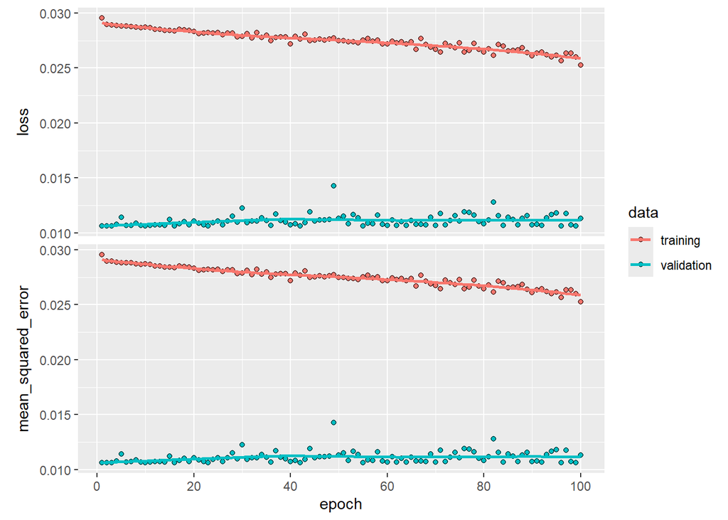

```r
# Build model
# Starts a new model using a sequential stack of layers.
# Layer 1.  32 neurons in the first hidden layer.
#     Applies ReLU activation (max(0, x)), good for non-linearity.
#     Number of input features (i.e., number of selected LASSO predictors).
# Layer 2.  16 neurons, again with ReLU.
# Layer 3.  1 output neuron: predicting a return.
model <- keras_model_sequential() %>%
  layer_dense(units = 32, activation = "relu", input_shape = ncol(X_train_nn)) %>%
  layer_dense(units = 16, activation = "relu") %>%
  layer_dense(units = 1)  # output layer

# Compile model
# Mean Squared Error is the objective to minimize (standard for regression).
# Uses the Adam optimizer, which is adaptive and works well with most problems.
# Also tracks MSE while training, for reporting
model %>% compile(
  loss = "mse",
  optimizer = optimizer_adam(learning_rate = 0.001),
  metrics = list("mean_squared_error")
)

# Train model
# Train the model for 100 full passes through the data.
# Use mini-batches of 128 rows for updates (tradeoff between speed and stability).
# Monitors performance on validation set at the end of each epoch.
history <- model %>% fit(
  x = X_train_nn,
  y = y_train_nn,
  epochs = 100,
  batch_size = 128,
  validation_data = list(X_val_nn, y_val_nn),
  verbose = 0
)
plot(history)
```

Evaluate on Test Set

```r
# Predict and calculate RMSE
pred_nn <- model %>% predict(X_test_nn)
```

```
## 853/853 - 0s - 368ms/epoch - 431us/step
```

```r
rmse <- function(actual, predicted) {
  sqrt(mean((actual - predicted)^2))
}

cat("Neural Network Test RMSE:", rmse(y_test_nn, pred_nn), "\n")
```

```
## Neural Network Test RMSE: 0.2818571
```

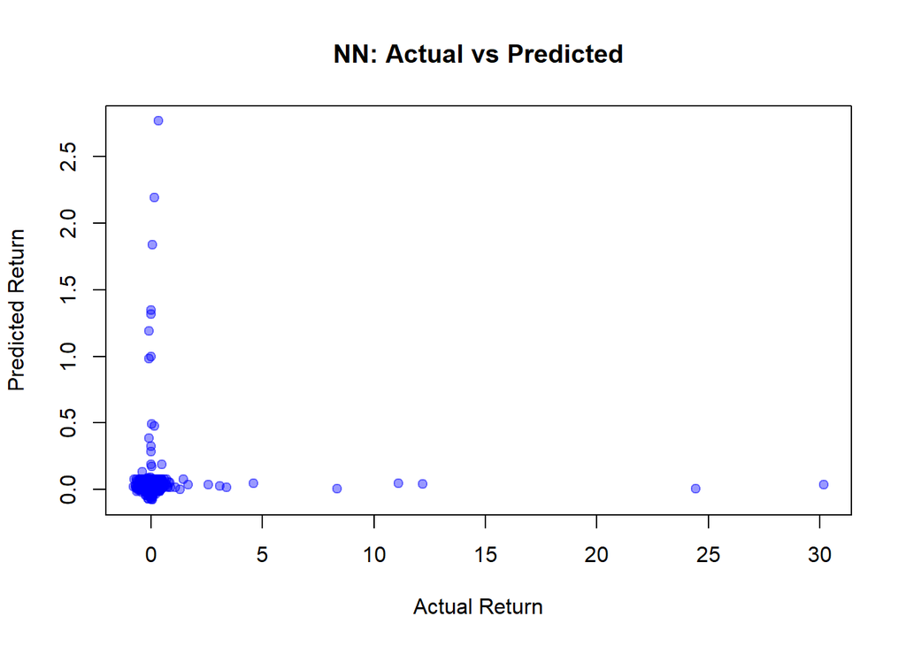

```r
plot(y_test_nn, pred_nn,
     xlab = "Actual Return",
     ylab = "Predicted Return",
     main = "NN: Actual vs Predicted",
     pch = 19, col = rgb(0,0,1,0.4))
```

We see most returns are clustering around 0 as expected in real stock data. For some points with actual return close to 0, the model predicts much higher values from 1% to 3%, this may suggests the model might be capturing noise in some input combinations. We also see that for stock with actual return greater than 5%, the predictions stay flay between 0 and 0.5% which may indicate that our model does not extrapolate well to large moves.

```r
library(elasticnet)
# Run SPCA for dimensionality reduction
X_spca <- as.matrix(training_set[, features])

spca_result <- suppressMessages(spca(X_spca,
                    K = 5,                      # Number of components
                    type = "predictor",
                    sparse = "penalty",
                    para = rep(0.4, 5),         # Sparsity level per component
                    trace = FALSE))
```

```
## You may wish to restart and use a more efficient way
## let the argument x be the sample covariance/correlation matrix and set type=Gram
```

```r
print(spca_result$loadings)
```

```
##                                          PC1          PC2          PC3
## Advt_12M_Usd                    0.1448406158  0.075939988  0.196928016
## Advt_3M_Usd                     0.1458600052  0.074618454  0.194715442
## Advt_6M_Usd                     0.1458914638  0.075231674  0.195826975
## Asset_Turnover                  0.0070774913 -0.116815817  0.190443995
## Bb_Yld                          0.0632709346 -0.014579481  0.011570718
## Bv                              0.1418513300  0.134430402  0.097705837
## Capex_Ps_Cf                     0.0350299497  0.099517998  0.077218204
## Capex_Sales                    -0.0048856673  0.056686426  0.028771311
## Cash_Div_Cf                     0.0475463301  0.065602861 -0.140644084
## Cash_Per_Share                  0.1151470474 -0.064038376 -0.034735871
## Cf_Sales                        0.0852897112  0.007846297 -0.148757723
## Debtequity                      0.0177902178  0.175473064 -0.084090166
## Div_Yld                         0.0481685324  0.084717908 -0.138958054
## Dps                             0.0801713309  0.093417238 -0.127398272
## Ebit_Bv                         0.1107788401  0.002138555 -0.143343479
## Ebit_Noa                        0.1013256658 -0.081481341 -0.128556449
## Ebit_Oa                         0.1056173784 -0.083948339 -0.148590559
## Ebit_Ta                         0.1097433334 -0.069847958 -0.151651748
## Ebitda_Margin                   0.0835351070  0.042916123 -0.215564959
## Eps                             0.1487343829  0.015742728 -0.075129545
## Eps_Basic                       0.1477225283  0.015942971 -0.073582758
## Eps_Basic_Gr                    0.0528954354 -0.048271981 -0.008390019
## Eps_Contin_Oper                 0.1425339067  0.014798553 -0.070357993
## Eps_Dil                         0.1484198657  0.016921826 -0.075190547
## Ev                              0.1633336748  0.131007617  0.102649967
## Ev_Ebitda                       0.0096831484 -0.033313251  0.109225255
## Fa_Ci                           0.0115262694  0.071464079  0.062682735
## Fcf                             0.1689916705 -0.009671218  0.024793814
## Fcf_Bv                          0.1264997650 -0.099887908 -0.041121942
## Fcf_Ce                          0.1010829133 -0.091673530 -0.067353706
## Fcf_Margin                      0.1099551885 -0.079506961 -0.135976092
## Fcf_Noa                         0.1125911156 -0.156196614 -0.011245650
## Fcf_Oa                          0.1140130032 -0.168995266  0.026070418
## Fcf_Ta                          0.1200096379 -0.163038452  0.021902669
## Fcf_Tbv                         0.0639759849 -0.073137980 -0.031260786
## Fcf_Toa                         0.0907390111 -0.135311056  0.014314125
## Fcf_Yld                         0.0866553700 -0.057416313 -0.093243621
## Free_Ps_Cf                      0.1150044679 -0.063896911 -0.034690706
## Int_Rev                         0.0202355332  0.015806595 -0.030946000
```

[output cut: 133 more lines]

```
## Roce                            0.0492001820  3.117862e-02
## Roe                             0.1655240140  4.755360e-02
## Sales_Ps                        0.0312220344  3.384326e-01
## Share_Turn_12M                 -0.0165947871 -1.198502e-01
## Share_Turn_3M                  -0.0140175765 -1.185948e-01
## Share_Turn_6M                  -0.0148477833 -1.198959e-01
## Ta                             -0.0568284710  3.648646e-03
## Tev_Less_Mktcap                -0.0321260353  1.253339e-02
## Tot_Debt_Rev                   -0.0530240873 -1.125651e-01
## Total_Capital                  -0.0399188489 -2.387821e-02
## Total_Debt                     -0.0488269997  1.126551e-02
## Total_Debt_Capital             -0.0533332214  1.811568e-02
## Total_Liabilities_Total_Assets -0.0849551613  9.902294e-02
## Vol1Y_Usd                      -0.0444493066 -4.070799e-02
## Vol3Y_Usd                      -0.0515697254 -5.472283e-02
```

Start NN under SPCA model

```r
# Project SPCA components
X_val_spca <- as.matrix(validation_set[, features])
X_test_spca <- as.matrix(testing_set[, features])

Z_train <- X_spca %*% spca_result$loadings
Z_val   <- X_val_spca %*% spca_result$loadings
Z_test  <- X_test_spca %*% spca_result$loadings
```

```r
# Train NN on SPCA components
model_spca <- keras_model_sequential() %>%
  layer_dense(units = 32, activation = "relu", input_shape = ncol(Z_train)) %>%
  layer_dense(units = 16, activation = "relu") %>%
  layer_dense(units = 1)  # output layer for regression

# Compile model
model_spca %>% compile(
  loss = "mse",
  optimizer = optimizer_adam(learning_rate = 0.001),
  metrics = list("mean_squared_error")
)
```

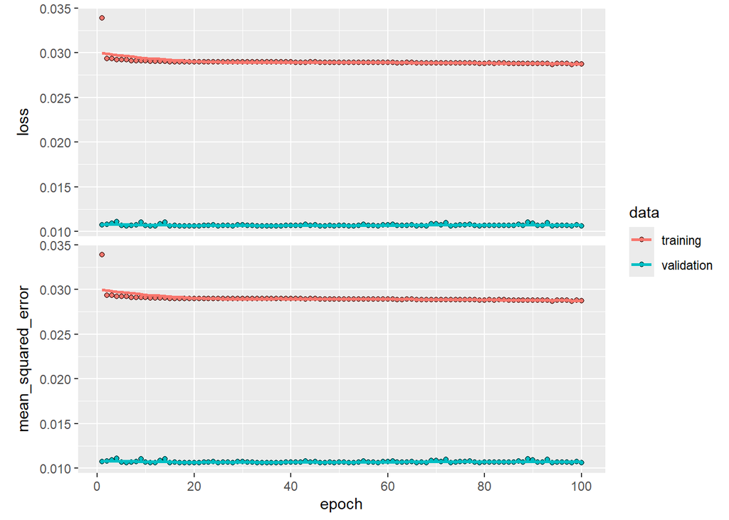

```r
history_spca <- model_spca %>% fit(
  x = Z_train,
  y = y_train_nn,
  epochs = 100,
  batch_size = 128,
  validation_data = list(Z_val, y_val_nn),
  verbose = 0  # quiet training
)

plot(history_spca)
```

```r
# Predict on test set
pred_spca <- model_spca %>% predict(Z_test)
```

```
## 853/853 - 0s - 351ms/epoch - 411us/step
```

```r
# Calculate RMSE
rmse <- function(actual, predicted) {
  sqrt(mean((actual - predicted)^2))
}

cat("SPCA + NN Test RMSE:", rmse(y_test_nn, pred_spca), "\n")
```

```
## SPCA + NN Test RMSE: 0.28008
```

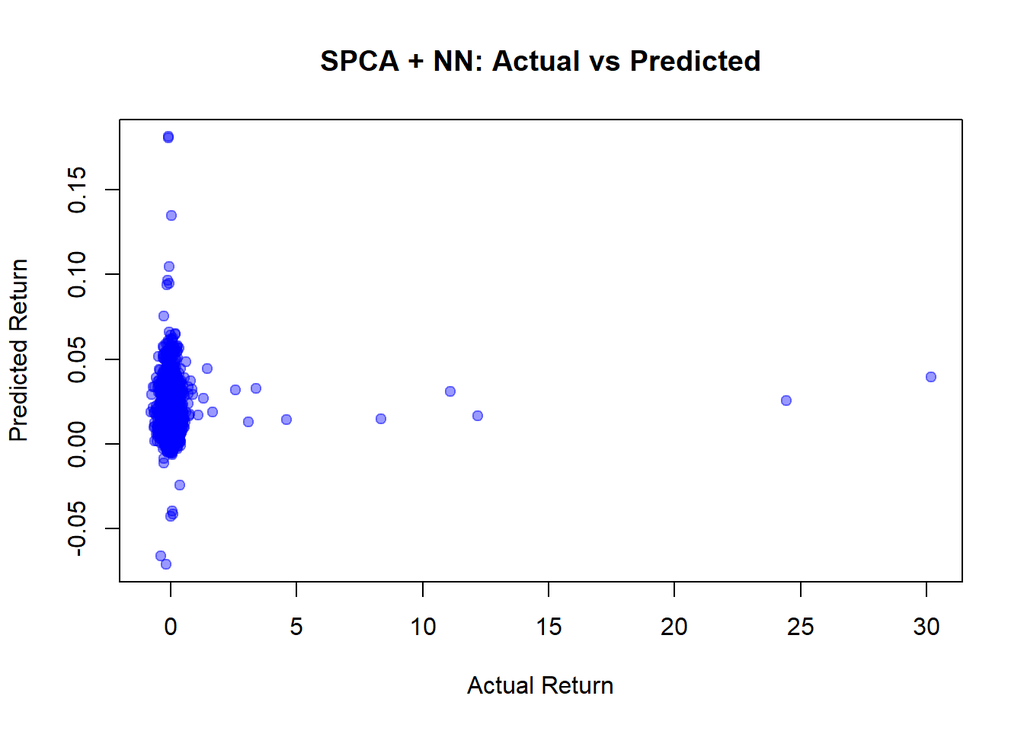

```r
plot(y_test_nn, pred_spca,
     xlab = "Actual Return",
     ylab = "Predicted Return",
     main = "SPCA + NN: Actual vs Predicted",
     pch = 19, col = rgb(0, 0, 1, 0.4))
```

Portfolio Construction

```r
# Add predictions back to test set
testing_set_lasso <- testing_set %>%
  mutate(pred_return = as.numeric(pred_nn),
         model = "LASSO_NN")

testing_set_spca <- testing_set %>%
  mutate(pred_return = as.numeric(pred_spca),
         model = "SPCA_NN")

# Combine into one dataset
portfolio_data <- bind_rows(testing_set_lasso, testing_set_spca)

# Rank stocks by predicted return within each date and model
portfolio_data <- portfolio_data %>%
  group_by(model, date) %>%
  mutate(rank = percent_rank(pred_return)) %>%
  ungroup()

# Label long-short portfolio buckets
portfolio_data <- portfolio_data %>%
  mutate(port_group = case_when(
    rank >= 0.9 ~ "Top 10%",      # Long
    rank <= 0.1 ~ "Bottom 10%",   # Short
    TRUE ~ "Middle"
  ))

# Calculate average return per group
portfolio_returns <- portfolio_data %>%
  filter(port_group != "Middle") %>%
  group_by(model, date, port_group) %>%
  summarise(avg_actual_return = mean(target_return), .groups = "drop") %>%
  pivot_wider(names_from = port_group, values_from = avg_actual_return) %>%
  mutate(long_short_return = `Top 10%` - `Bottom 10%`)
```

```r
# Summary stats
performance_summary <- portfolio_returns %>%
  group_by(model) %>%
  summarise(
    avg_monthly_return = mean(long_short_return, na.rm = TRUE),
    sd_monthly_return = sd(long_short_return, na.rm = TRUE),
    sharpe_ratio = avg_monthly_return / sd_monthly_return,
    .groups = "drop"
  )

print(performance_summary)
```

```
## # A tibble: 2 × 4
##   model    avg_monthly_return sd_monthly_return sharpe_ratio
##   <chr>                 <dbl>             <dbl>        <dbl>
## 1 LASSO_NN             0.0149            0.0717        0.208
## 2 SPCA_NN              0.0210            0.0761        0.276
```

Do a top-20% only long-only portfolio instead of long-short

```r
# Add predictions back to test set (already done if continuing)
testing_set_lasso <- testing_set %>%
  mutate(pred_return = as.numeric(pred_nn),
         model = "LASSO_NN")

testing_set_spca <- testing_set %>%
  mutate(pred_return = as.numeric(pred_spca),
         model = "SPCA_NN")

# Combine both models
portfolio_data <- bind_rows(testing_set_lasso, testing_set_spca)

# Rank stocks within each date and model
portfolio_data <- portfolio_data %>%
  group_by(model, date) %>%
  mutate(rank = percent_rank(pred_return)) %>%
  ungroup()

# Filter top 20% (long-only portfolio)
top_20_data <- portfolio_data %>%
  filter(rank >= 0.8)

# Calculate average monthly return
long_only_returns <- top_20_data %>%
  group_by(model, date) %>%
  summarise(top20_return = mean(target_return), .groups = "drop")

# Performance summary
long_only_summary <- long_only_returns %>%
  group_by(model) %>%
  summarise(
    avg_monthly_return = mean(top20_return, na.rm = TRUE),
    sd_monthly_return = sd(top20_return, na.rm = TRUE),
    sharpe_ratio = avg_monthly_return / sd_monthly_return,
    .groups = "drop"
  )

print(long_only_summary)
```

```
## # A tibble: 2 × 4
##   model    avg_monthly_return sd_monthly_return sharpe_ratio
##   <chr>                 <dbl>             <dbl>        <dbl>
## 1 LASSO_NN             0.0144            0.0714        0.202
## 2 SPCA_NN              0.0218            0.0657        0.331
```